# Solving an Image-Based Environment

In this task, we are training a Deep Q-Network (DQN) to play an **image-based** Gymnasium environment (Atari Pong) **directly from pixels**. Following the classic DQN setup, we preprocess raw frames (grayscale, resize, stack), use a **CNN** to approximate action-values **(Q(s,a))**, train with **experience replay** and a periodically synced **target network**, and evaluate a **greedy** policy.

**Imports**

```python
# Install Atari extras + ROM downloader
!pip -q install "gymnasium[atari]" ale-py autorom AutoROM.accept-rom-license

# Download Atari ROMs non-interactively
import sys, subprocess, importlib.util
subprocess.run(
    [sys.executable, "-m", "AutoROM", "--accept-license", "--install-dir", "/root/.atari_roms", "--quiet"],
    check=False,)
```

```
CompletedProcess(args=['/usr/bin/python3', '-m', 'AutoROM', '--accept-license', '--install-dir', '/root/.atari_roms', '--quiet'], returncode=1)
```

```python
# Core
import os, math, time, random, collections
from collections import deque
from typing import NamedTuple, Deque, Tuple

# Numeric / plotting
import numpy as np
import matplotlib.pyplot as plt

# Torch
import torch
import torch.nn as nn
import torch.optim as optim

# Gymnasium / Atari helpers
import gymnasium as gym
from gymnasium.wrappers import AtariPreprocessing, FrameStackObservation
import ale_py
```

**Device & reproducibility**

```python
device = torch.device("cuda" if torch.cuda.is_available() else "cpu")
SEED = 1227
random.seed(SEED)
np.random.seed(SEED)
torch.manual_seed(SEED)
if torch.cuda.is_available():
    torch.cuda.manual_seed_all(SEED)

torch.backends.cudnn.deterministic = True
torch.backends.cudnn.benchmark = False

print(f"Device: {device}, SEED = {SEED}")
```

```
Device: cuda, SEED = 1227
```

# **1.0 Environment setup**

We create an Atari image-based environment (Pong) and wrap it with standard preprocessing so the agent learns from compact visual inputs. `AtariPreprocessing` turns raw RGB frames into 84×84 grayscale and repeats each chosen action for a few frames (frame-skip) to reduce compute and smooth dynamics. Then we stack 4 consecutive frames so the agent can infer short-term motion (like ball direction). Finally, we reset with a fixed seed for reproducibility and print the observation and action space details.

```python
ENV_ID = "ALE/Pong-v5"

# Turn OFF ALE's internal frameskip and let AtariPreprocessing handle it
env = gym.make(ENV_ID, frameskip=1, render_mode=None)

env = AtariPreprocessing(
    env,
    grayscale_obs=True,
    screen_size=84,
    frame_skip=4,      # frameskip handled here
    terminal_on_life_loss=True,
    scale_obs=False,
)

# Stack 4 frames
env = FrameStackObservation(env, stack_size=4)

obs, info = env.reset(seed=SEED)
print("Observation shape:", env.observation_space.shape)  # expected: (4, 84, 84)
print("Action space:", env.action_space, "| n =", env.action_space.n)
```

```
Observation shape: (4, 84, 84)
Action space: Discrete(6) | n = 6
```

## **1.1 State pipeline (frames → tensors)**

Each observation already arrives as a stacked **grayscale** tensor in **channels-first** format `(C,H,W) = (4, 84, 84)`. Before every forward pass, we:

- cast to **float32**,
- **normalize** pixel values to `[0, 1]` by dividing by 255.0,
- and add a **batch dimension**, yielding `(1, 4, 84, 84)`.

This standardized tensor is used identically by the online and target Q-networks during training and evaluation.

```python
def obs_to_tensor(obs, device):
    arr = np.asarray(obs, dtype=np.uint8)
    if arr.ndim == 2:            # single frame (H,W)
        arr = arr[None, ...]     # (1,H,W)
    arr = arr.astype(np.float32) / 255.0
    t = torch.from_numpy(arr).to(device)   # (C,H,W)
    return t.unsqueeze(0)                  # (1,C,H,W)

# quick sanity check on the current obs
s0 = obs_to_tensor(obs, device)
print("Preprocessed state shape:", tuple(s0.shape))  # expect: (1, 4, 84, 84)
```

```
Preprocessed state shape: (1, 4, 84, 84)
```

# **2.0 CNN Q-network (images → Q(s,a))**

We replace the MLP used for vector states with a small convolutional Q-network. The model takes a `(4,84,84)` frame stack and outputs one Q-value per discrete action. A standard, fast architecture (Conv8×8/32, stride 4 → Conv4×4/64, stride 2 → Conv3×3/64, stride 1 → FC 512 → linear to n_actions) works well on Pong.

```python
class CNNQNet(nn.Module):
    def __init__(self, in_channels: int, n_actions: int):
        super().__init__()
        self.features = nn.Sequential(
            nn.Conv2d(in_channels, 32, kernel_size=8, stride=4), nn.ReLU(inplace=True),
            nn.Conv2d(32, 64, kernel_size=4, stride=2),         nn.ReLU(inplace=True),
            nn.Conv2d(64, 64, kernel_size=3, stride=1),         nn.ReLU(inplace=True),
        )
        # For 84×84 input with the above convs, the feature map is 64×7×7 => 3136
        self.head = nn.Sequential(
            nn.Linear(3136, 512), nn.ReLU(inplace=True),
            nn.Linear(512, n_actions),
        )
        self.apply(self._init_weights)

    @staticmethod
    def _init_weights(m):
        if isinstance(m, (nn.Conv2d, nn.Linear)):
            nn.init.kaiming_normal_(m.weight, nonlinearity="relu")
            if m.bias is not None:
                nn.init.zeros_(m.bias)

    def forward(self, x: torch.Tensor) -> torch.Tensor:
        x = self.features(x)           # (B,64,7,7)
        x = x.view(x.size(0), -1)      # (B,3136)
        return self.head(x)            # (B,n_actions)

# Instantiate online (policy) and target networks
n_actions = env.action_space.n
policy_q = CNNQNet(in_channels=4, n_actions=n_actions).to(device)
target_q = CNNQNet(in_channels=4, n_actions=n_actions).to(device)
target_q.load_state_dict(policy_q.state_dict())
target_q.eval()

# Sanity check on a preprocessed state from 1.1
with torch.no_grad():
    test_q = policy_q(s0)  # s0 is (1,4,84,84) float32 in [0,1]
print("Q output shape:", tuple(test_q.shape))  # expect: (1, n_actions)
```

```
Q output shape: (1, 6)
```

# **3.0 Replay buffer (uint8 storage → normalized tensors)**

We reuse an experience replay buffer but store frames as `uint8` to save memory. Each transition is (`s, a, r, s_next, done`), where s and s_next are stacked frames in **CHW** layout (`4×84×84`). When sampling a minibatch, we convert images to float32, scale to `[0,1]`, and move everything to the selected device.

```python
Transition = collections.namedtuple("Transition", ("s", "a", "r", "s2", "done"))

class ReplayBuffer:
    def __init__(self, capacity: int = 200_000):
        self.buf: Deque[Transition] = deque(maxlen=capacity)

    def __len__(self) -> int:
        return len(self.buf)

    def push(self, s: np.ndarray, a: int, r: float, s2: np.ndarray, done: bool) -> None:
        # Ensure compact storage
        self.buf.append(
            Transition(
                s=np.asarray(s, dtype=np.uint8).copy(),
                a=int(a),
                r=float(r),
                s2=np.asarray(s2, dtype=np.uint8).copy(),
                done=bool(done),
            )
        )

    def sample(self, batch_size: int, device: torch.device):
        batch = random.sample(self.buf, batch_size)

        # Stack images as (B,C,H,W) uint8, then to float32 in [0,1]
        S  = torch.from_numpy(np.stack([t.s  for t in batch], axis=0)).to(device).float() / 255.0
        S2 = torch.from_numpy(np.stack([t.s2 for t in batch], axis=0)).to(device).float() / 255.0

        A = torch.tensor([t.a for t in batch], dtype=torch.long, device=device).unsqueeze(1)  # (B,1)
        R = torch.tensor([t.r for t in batch], dtype=torch.float32, device=device).unsqueeze(1)  # (B,1)
        D = torch.tensor([t.done for t in batch], dtype=torch.float32, device=device).unsqueeze(1)  # (B,1)

        return S, A, R, S2, D

# Instantiate a buffer and do a quick smoke test insert with the reset obs
replay = ReplayBuffer(capacity=200_000)
replay.push(np.asarray(obs), a=0, r=0.0, s2=np.asarray(obs), done=False)
print("Replay size (after 1 push):", len(replay))
```

```
Replay size (after 1 push): 1
```

# **4.0 ε-greedy policy (action selection)**

During training we balance exploration and exploitation: with `probability ε` we pick a random action or otherwise we pick the `argmax Q(s,·)` from the online network. We start with a high ε and anneal it linearly toward a small floor as training progresses.

```python
def linear_epsilon(step: int, eps_start=1.0, eps_end=0.01, decay_steps=500_000):
    """Linearly anneal ε from eps_start to eps_end over decay_steps."""
    if decay_steps <= 0:
        return eps_end
    t = max(0, min(step, decay_steps))
    return eps_start + (eps_end - eps_start) * (t / decay_steps)

def select_action(policy_net: nn.Module, state_tensor: torch.Tensor, step: int,
                  n_actions: int, device: torch.device,
                  eps_start=1.0, eps_end=0.01, decay_steps=500_000) -> Tuple[int, float]:
    """
    state_tensor: (1,4,84,84) float32 in [0,1]
    returns (action:int, epsilon:float)
    """
    epsilon = linear_epsilon(step, eps_start, eps_end, decay_steps)
    if random.random() < epsilon:
        a = random.randrange(n_actions)
        return a, epsilon
    with torch.no_grad():
        q = policy_net(state_tensor.to(device))     # (1, n_actions)
        a = int(q.argmax(dim=1).item())
    return a, float(epsilon)

# Quick smoke test on s0 from 1.1
a, eps = select_action(policy_q, s0, step=0, n_actions=n_actions, device=device)
print(f"ε={eps:.2f}, selected action={a}")
```

```
ε=1.00, selected action=0
```

# **5.0 DDQN targets & optimization (loss, optimizer, target sync)**

We compute Double DQN targets for stability: the online net selects the best next action, while the target net evaluates it. We minimize Huber loss between Q(s,a) and the target, and periodically sync target parameters from the online net.

```python
gamma = 0.99
huber = nn.SmoothL1Loss()  # Huber loss

def ddqn_update(batch, policy_net, target_net, optimizer, gamma, huber):
    S, A, R, S2, D = batch  # S/S2: (B,4,84,84) in [0,1]
    # Q(s,a) from online
    q = policy_net(S).gather(1, A)  # (B,1)

    # a* = argmax_a Q_online(s', a)
    with torch.no_grad():
        a_star = policy_net(S2).argmax(dim=1, keepdim=True)  # (B,1)
        q_target_next = target_net(S2).gather(1, a_star)     # (B,1)
        y = R + gamma * (1.0 - D) * q_target_next            # (B,1)

    loss = huber(q, y)

    optimizer.zero_grad(set_to_none=True)
    loss.backward()
    torch.nn.utils.clip_grad_norm_(policy_net.parameters(), max_norm=10.0)
    optimizer.step()

    return float(loss.item())
```

# **6.0 Training loop (collect → learn)**

We first warm up the replay buffer with random actions, then alternate between acting (`ε-greedy`), storing transitions, and learning (one gradient step per env step once warm-up is done). We track episodic returns, ε, and loss for plotting. A small optional reward clip to `{−1,0,+1}` helps stabilize Atari training.

```python
def dqn_update(batch, policy_net, target_net, optimizer, gamma=0.99):
    """Vanilla DQN target: max_a' Q_target(s', a')."""
    S, A, R, S2, D = batch
    q = policy_net(S).gather(1, A)
    with torch.no_grad():
        q_next = target_net(S2).max(dim=1, keepdim=True).values
        y = R + gamma * (1.0 - D) * q_next
    loss = nn.SmoothL1Loss()(q, y)
    optimizer.zero_grad(set_to_none=True)
    loss.backward()
    torch.nn.utils.clip_grad_norm_(policy_net.parameters(), 10.0)
    optimizer.step()
    return float(loss.item())

def train_agent(env, policy_net, target_net, replay,
                total_steps=500_000, warmup_steps=40_000,
                batch_size=32, eps_start=1.0, eps_end=0.01, eps_decay_steps=500_000,
                gamma=0.99, lr=2.5e-4, target_sync_every=2_000,
                use_ddqn=True, clip_reward=True, log_every=1_000, seed=SEED):
    """
    Returns logs: (episode_returns, eps_history, loss_history)
    """
    optimizer = optim.RMSprop(policy_net.parameters(), lr=lr, alpha=0.95, eps=0.01)
    huber = nn.SmoothL1Loss()

    ep_returns, eps_hist, loss_hist = [], [], []
    grad_step = 0
    steps = 0
    ep_ret = 0.0

    obs, _ = env.reset(seed=seed)
    s = obs_to_tensor(obs, device)  # (1,4,84,84)

    while steps < total_steps:
        # ε-greedy action from current state
        a, eps = select_action(policy_net, s, steps, env.action_space.n, device,
                               eps_start, eps_end, eps_decay_steps)

        # env step
        obs2, r, terminated, truncated, _ = env.step(a)
        done = terminated or truncated
        if clip_reward:
            r = float(np.sign(r))
        ep_ret += r

        # store transition (raw CHW uint8 for s and s2)
        replay.push(np.asarray(obs), a, float(r), np.asarray(obs2), bool(done))

        # learning step after warm-up
        if steps >= warmup_steps and len(replay) >= batch_size:
            batch = replay.sample(batch_size, device)
            if use_ddqn:
                loss = ddqn_update(batch, policy_net, target_net, optimizer, gamma, huber)
            else:
                loss = dqn_update(batch, policy_net, target_net, optimizer, gamma=gamma)
            loss_hist.append(loss)
            grad_step += 1
            # target sync (single source of truth)
            if grad_step % target_sync_every == 0:
                target_net.load_state_dict(policy_net.state_dict())

        # advance global step & epsilon history
        steps += 1
        eps_hist.append(float(eps))

        # episode handling + next state tensor
        if done:
            ep_returns.append(ep_ret)
            ep_ret = 0.0
            obs, _ = env.reset()
        else:
            obs = obs2
        s = obs_to_tensor(obs, device)

        # lightweight logging
        if steps % log_every == 0:
            last10 = np.mean(ep_returns[-10:]) if ep_returns else float('nan')
            last_loss = loss_hist[-1] if loss_hist else float('nan')
            print(f"steps={steps:,}  episodes={len(ep_returns):,}  "
                  f"avg_return_10={last10:.2f}  eps={eps:.3f}  last_loss={last_loss:.4f}")

    return ep_returns, eps_hist, loss_hist
```

## **6.1 Train DQN (Vanilla, from Part II)**

We run a vanilla DQN pass on Pong using the shared loop. We initialize fresh CNN online/target networks, a new replay buffer, and train with ε-greedy, replay, and target sync. We log episodic returns, ε, and loss for plotting, and save the weights for later comparison.

```python
# Fresh networks for a clean DQN run
dqn_policy = CNNQNet(in_channels=4, n_actions=env.action_space.n).to(device)
dqn_target = CNNQNet(in_channels=4, n_actions=env.action_space.n).to(device)
dqn_target.load_state_dict(dqn_policy.state_dict())
dqn_target.eval()

# Fresh replay buffer
replay_dqn = ReplayBuffer(capacity=200_000)

# Training config
TOTAL_STEPS_DQN   = 2_000_000
WARMUP_STEPS      = 40_000
BATCH_SIZE        = 32
EPS_DECAY_STEPS   = 500_000
GAMMA             = 0.99
LR                = 2.5e-4
SYNC_EVERY        = 10_000

# Ensure train mode for the online net
dqn_policy.train()

# Train vanilla DQN (use_ddqn=False)
dqn_returns, dqn_eps, dqn_loss = train_agent(
    env, dqn_policy, dqn_target, replay_dqn,
    total_steps=TOTAL_STEPS_DQN,
    warmup_steps=WARMUP_STEPS,
    batch_size=BATCH_SIZE,
    eps_start=1.0, eps_end=0.01, eps_decay_steps=EPS_DECAY_STEPS,
    gamma=GAMMA, lr=LR, target_sync_every=SYNC_EVERY,
    use_ddqn=False,            # vanilla DQN
    clip_reward=True, log_every=1_000, seed=SEED
)

# Save weights/logs for later comparison and evaluation
os.makedirs("artifacts", exist_ok=True)
torch.save(dqn_policy.state_dict(), "artifacts/pong_dqn_policy.pth")
np.savez_compressed("artifacts/pong_dqn_logs.npz",
                    returns=np.array(dqn_returns, dtype=np.float32),
                    eps=np.array(dqn_eps, dtype=np.float32),
                    loss=np.array(dqn_loss, dtype=np.float32))

print(f"[DQN] episodes={len(dqn_returns)}, "
      f"last10_avg={np.mean(dqn_returns[-10:]) if len(dqn_returns)>=10 else float('nan'):.2f}")
```

```
steps=1,000  episodes=0  avg_return_10=nan  eps=0.998  last_loss=nan
steps=2,000  episodes=2  avg_return_10=-19.50  eps=0.996  last_loss=nan
steps=3,000  episodes=3  avg_return_10=-20.00  eps=0.994  last_loss=nan
steps=4,000  episodes=4  avg_return_10=-20.00  eps=0.992  last_loss=nan
steps=5,000  episodes=5  avg_return_10=-20.20  eps=0.990  last_loss=nan
steps=6,000  episodes=6  avg_return_10=-20.17  eps=0.988  last_loss=nan
steps=7,000  episodes=7  avg_return_10=-20.14  eps=0.986  last_loss=nan
steps=8,000  episodes=8  avg_return_10=-20.12  eps=0.984  last_loss=nan
steps=9,000  episodes=9  avg_return_10=-20.11  eps=0.982  last_loss=nan
steps=10,000  episodes=10  avg_return_10=-20.10  eps=0.980  last_loss=nan
steps=11,000  episodes=11  avg_return_10=-20.30  eps=0.978  last_loss=nan
steps=12,000  episodes=12  avg_return_10=-20.10  eps=0.976  last_loss=nan
steps=13,000  episodes=13  avg_return_10=-20.10  eps=0.974  last_loss=nan
steps=14,000  episodes=14  avg_return_10=-20.10  eps=0.972  last_loss=nan
steps=15,000  episodes=16  avg_return_10=-20.20  eps=0.970  last_loss=nan
steps=16,000  episodes=17  avg_return_10=-20.20  eps=0.968  last_loss=nan
steps=17,000  episodes=18  avg_return_10=-20.20  eps=0.966  last_loss=nan
steps=18,000  episodes=19  avg_return_10=-20.10  eps=0.964  last_loss=nan
steps=19,000  episodes=20  avg_return_10=-20.20  eps=0.962  last_loss=nan
steps=20,000  episodes=21  avg_return_10=-20.20  eps=0.960  last_loss=nan
steps=21,000  episodes=22  avg_return_10=-20.20  eps=0.958  last_loss=nan
steps=22,000  episodes=23  avg_return_10=-20.20  eps=0.956  last_loss=nan
steps=23,000  episodes=24  avg_return_10=-20.20  eps=0.954  last_loss=nan
steps=24,000  episodes=25  avg_return_10=-20.00  eps=0.952  last_loss=nan
steps=25,000  episodes=26  avg_return_10=-20.00  eps=0.951  last_loss=nan
steps=26,000  episodes=27  avg_return_10=-20.10  eps=0.949  last_loss=nan
steps=27,000  episodes=28  avg_return_10=-20.10  eps=0.947  last_loss=nan
steps=28,000  episodes=29  avg_return_10=-20.20  eps=0.945  last_loss=nan
steps=29,000  episodes=30  avg_return_10=-20.20  eps=0.943  last_loss=nan
steps=30,000  episodes=31  avg_return_10=-20.20  eps=0.941  last_loss=nan
steps=31,000  episodes=32  avg_return_10=-20.20  eps=0.939  last_loss=nan
steps=32,000  episodes=33  avg_return_10=-20.20  eps=0.937  last_loss=nan
steps=33,000  episodes=35  avg_return_10=-20.50  eps=0.935  last_loss=nan
steps=34,000  episodes=35  avg_return_10=-20.50  eps=0.933  last_loss=nan
steps=35,000  episodes=36  avg_return_10=-20.30  eps=0.931  last_loss=nan
steps=36,000  episodes=37  avg_return_10=-20.10  eps=0.929  last_loss=nan
steps=37,000  episodes=38  avg_return_10=-20.20  eps=0.927  last_loss=nan
steps=38,000  episodes=40  avg_return_10=-20.30  eps=0.925  last_loss=nan
steps=39,000  episodes=41  avg_return_10=-20.40  eps=0.923  last_loss=nan
steps=40,000  episodes=42  avg_return_10=-20.60  eps=0.921  last_loss=nan
```

[output cut: 1946 more lines]

```
steps=1,987,000  episodes=1,013  avg_return_10=5.00  eps=0.010  last_loss=0.0007
steps=1,988,000  episodes=1,013  avg_return_10=5.00  eps=0.010  last_loss=0.0017
steps=1,989,000  episodes=1,014  avg_return_10=3.00  eps=0.010  last_loss=0.0026
steps=1,990,000  episodes=1,014  avg_return_10=3.00  eps=0.010  last_loss=0.0017
steps=1,991,000  episodes=1,015  avg_return_10=3.10  eps=0.010  last_loss=0.0013
steps=1,992,000  episodes=1,015  avg_return_10=3.10  eps=0.010  last_loss=0.0055
steps=1,993,000  episodes=1,015  avg_return_10=3.10  eps=0.010  last_loss=0.0018
steps=1,994,000  episodes=1,016  avg_return_10=1.10  eps=0.010  last_loss=0.0013
steps=1,995,000  episodes=1,016  avg_return_10=1.10  eps=0.010  last_loss=0.0017
steps=1,996,000  episodes=1,016  avg_return_10=1.10  eps=0.010  last_loss=0.0024
steps=1,997,000  episodes=1,017  avg_return_10=2.40  eps=0.010  last_loss=0.0026
steps=1,998,000  episodes=1,017  avg_return_10=2.40  eps=0.010  last_loss=0.0064
steps=1,999,000  episodes=1,017  avg_return_10=2.40  eps=0.010  last_loss=0.0018
steps=2,000,000  episodes=1,018  avg_return_10=1.40  eps=0.010  last_loss=0.0008
[DQN] episodes=1018, last10_avg=1.40
```

## **6.1a DQN plots + greedy eval (saved artifacts)**

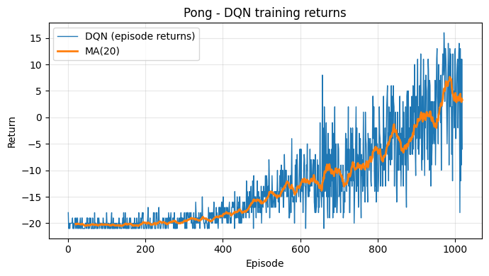

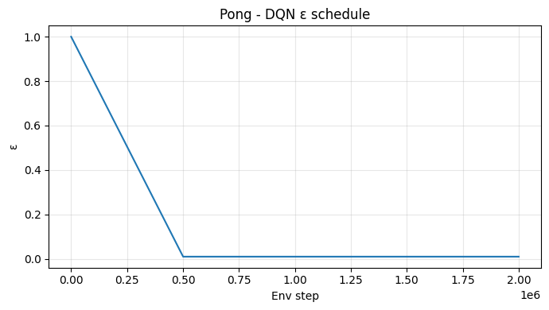

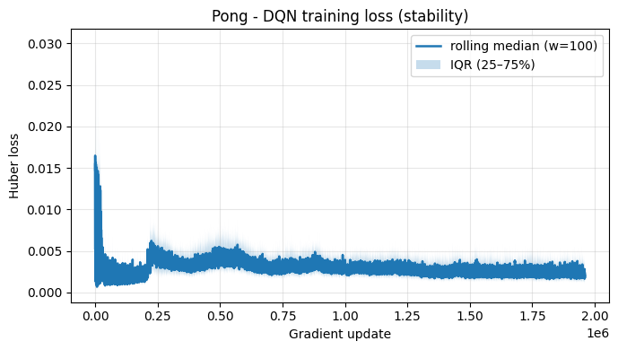

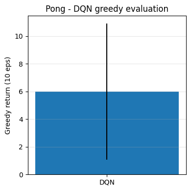

```
[DQN Greedy] mean=6.00, std=4.92, scores=[10.0, -7.0, 8.0, 9.0, 4.0, 5.0, 7.0, 9.0, 11.0, 4.0]
```

```python
os.makedirs("artifacts", exist_ok=True)

def moving_average(x, w=20):
    if len(x) == 0:
        return np.array([])
    w = max(1, int(w))
    if len(x) < w:
        return np.convolve(x, np.ones(len(x))/len(x), mode="valid")
    return np.convolve(x, np.ones(w)/w, mode="valid")

def rolling_quantiles(x, window=100):
    """Return (median, q25, q75) as arrays with same length as x (NaN-padded at start)."""
    n = len(x)
    m, q25, q75 = np.full(n, np.nan), np.full(n, np.nan), np.full(n, np.nan)
    if n == 0:
        return m, q25, q75
    w = max(1, int(window))
    for i in range(w-1, n):
        seg = x[i-w+1:i+1]
        m[i]   = np.median(seg)
        q25[i] = np.percentile(seg, 25.0)
        q75[i] = np.percentile(seg, 75.0)
    return m, q25, q75

# Episodic return (with MA(20))
plt.figure(figsize=(7,4))
plt.plot(np.arange(1, len(dqn_returns)+1), dqn_returns, linewidth=1, label="DQN (episode returns)")
ma = moving_average(dqn_returns, w=20)
if len(ma) > 0:
    xs = np.arange(20, 20+len(ma))
    plt.plot(xs, ma, linewidth=2, label="MA(20)")
plt.xlabel("Episode")
plt.ylabel("Return")
plt.title("Pong - DQN training returns")
plt.grid(True, alpha=0.3)
plt.legend()
plt.tight_layout()
plt.savefig("artifacts/pong_dqn_returns.png", dpi=150)
plt.show()
plt.close()

# Epsilon schedule vs steps
plt.figure(figsize=(7,4))
plt.plot(np.arange(1, len(dqn_eps)+1), dqn_eps, linewidth=1.5)
plt.xlabel("Env step")
plt.ylabel("ε")
plt.title("Pong - DQN ε schedule")
plt.grid(True, alpha=0.3)
plt.tight_layout()
plt.savefig("artifacts/pong_dqn_eps.png", dpi=150)
plt.show()
plt.close()

# Training loss (rolling median + IQR)
m, q25, q75 = rolling_quantiles(np.asarray(dqn_loss, dtype=float), window=100)
plt.figure(figsize=(7,4))
if len(dqn_loss) > 0:
    xs = np.arange(1, len(dqn_loss)+1)
    plt.plot(xs, m, linewidth=1.8, label="rolling median (w=100)")
    plt.fill_between(xs, q25, q75, alpha=0.25, label="IQR (25–75%)")
plt.xlabel("Gradient update")
plt.ylabel("Huber loss")
plt.title("Pong - DQN training loss (stability)")
plt.grid(True, alpha=0.3)
plt.legend()
plt.tight_layout()
plt.savefig("artifacts/pong_dqn_loss_recent.png", dpi=150)
plt.show()
plt.close()

# Greedy evaluation (10 eps)
def make_eval_env(env_id, seed=None):
    e = gym.make(env_id, frameskip=1, render_mode=None)
    e = AtariPreprocessing(e, grayscale_obs=True, screen_size=84, frame_skip=4, scale_obs=False)
    # terminal_on_life_loss is intentionally omitted here for full-game eval
    e = FrameStackObservation(e, stack_size=4)
    if seed is not None:
        e.reset(seed=seed)
    return e

@torch.no_grad()
def greedy_action(policy, s_tensor):
    q = policy(s_tensor)
    return int(q.argmax(1).item())

def evaluate_greedy(policy, env_id, n_episodes=10, max_steps=10000, seed_base=SEED):
    scores = []
    env = make_eval_env(env_id)
    try:
        for k in range(n_episodes):
            obs, _ = env.reset(seed=seed_base + k)
            s = obs_to_tensor(obs, device)
            total_r = 0.0
            for _ in range(max_steps):
                a = greedy_action(policy, s)
                obs2, r, terminated, truncated, _ = env.step(a)
                total_r += r
                if terminated or truncated:
                    break
                s = obs_to_tensor(obs2, device)
            scores.append(total_r)
    finally:
        env.close()
    return np.array(scores, dtype=np.float32)

# Put policy in eval mode just for inference here
dqn_policy.eval()
dqn_scores = evaluate_greedy(dqn_policy, ENV_ID, n_episodes=10, max_steps=20000, seed_base=SEED)
dqn_policy.train()

dqn_mean, dqn_std = float(np.mean(dqn_scores)), float(np.std(dqn_scores))

# Save a small NPZ so later we can make side-by-side overlays without re-running
np.savez_compressed("artifacts/pong_dqn_greedy.npz",
                    scores=dqn_scores, mean=np.array([dqn_mean]), std=np.array([dqn_std]))

# Bar with error bar
plt.figure(figsize=(4,4))
plt.bar([0], [dqn_mean], yerr=[dqn_std], width=0.6)
plt.xticks([0], ["DQN"])
plt.ylabel("Greedy return (10 eps)")
plt.title("Pong - DQN greedy evaluation")
plt.grid(True, axis="y", alpha=0.3)
plt.tight_layout()
plt.savefig("artifacts/pong_dqn_greedy_bar.png", dpi=150)
plt.show()
plt.close()

print(f"[DQN Greedy] mean={dqn_mean:.2f}, std={dqn_std:.2f}, scores={dqn_scores.tolist()}")
```

## **6.2 Train DDQN (improved, form Part III)**

We repeat the same setup as DQN but enable the Double DQN target. This keeps the comparison fair (same hyperparameters, same metrics) while reducing overestimation bias.

```python
# Fresh networks for a clean DDQN run
ddqn_policy = CNNQNet(in_channels=4, n_actions=env.action_space.n).to(device)
ddqn_target = CNNQNet(in_channels=4, n_actions=env.action_space.n).to(device)
ddqn_target.load_state_dict(ddqn_policy.state_dict())
ddqn_target.eval()

# Fresh replay buffer (match DQN)
replay_ddqn = ReplayBuffer(capacity=200_000)

# Same training config for a fair comparison
TOTAL_STEPS_DDQN  = 2_000_000
WARMUP_STEPS      = 40_000
BATCH_SIZE        = 32
EPS_DECAY_STEPS   = 500_000
GAMMA             = 0.99
LR                = 2.5e-4
SYNC_EVERY        = 10_000

# Ensure train mode for the online net
ddqn_policy.train()

# Train Double DQN (use_ddqn=True)
ddqn_returns, ddqn_eps, ddqn_loss = train_agent(
    env, ddqn_policy, ddqn_target, replay_ddqn,
    total_steps=TOTAL_STEPS_DDQN,
    warmup_steps=WARMUP_STEPS,
    batch_size=BATCH_SIZE,
    eps_start=1.0, eps_end=0.01, eps_decay_steps=EPS_DECAY_STEPS,
    gamma=GAMMA, lr=LR, target_sync_every=SYNC_EVERY,
    use_ddqn=True,             # Double DQN
    clip_reward=True, log_every=1_000, seed=SEED
)

# Save weights/logs for later comparison and evaluation
os.makedirs("artifacts", exist_ok=True)
torch.save(ddqn_policy.state_dict(), "artifacts/pong_ddqn_policy.pth")
np.savez_compressed("artifacts/pong_ddqn_logs.npz",
                    returns=np.array(ddqn_returns, dtype=np.float32),
                    eps=np.array(ddqn_eps, dtype=np.float32),
                    loss=np.array(ddqn_loss, dtype=np.float32))

print(f"[DDQN] episodes={len(ddqn_returns)}, "
      f"last10_avg={np.mean(ddqn_returns[-10:]) if len(ddqn_returns)>=10 else float('nan'):.2f}")
```

```
steps=1,000  episodes=1  avg_return_10=-20.00  eps=0.998  last_loss=nan
steps=2,000  episodes=2  avg_return_10=-19.50  eps=0.996  last_loss=nan
steps=3,000  episodes=3  avg_return_10=-19.33  eps=0.994  last_loss=nan
steps=4,000  episodes=4  avg_return_10=-19.75  eps=0.992  last_loss=nan
steps=5,000  episodes=5  avg_return_10=-19.80  eps=0.990  last_loss=nan
steps=6,000  episodes=6  avg_return_10=-20.00  eps=0.988  last_loss=nan
steps=7,000  episodes=7  avg_return_10=-20.00  eps=0.986  last_loss=nan
steps=8,000  episodes=8  avg_return_10=-20.12  eps=0.984  last_loss=nan
steps=9,000  episodes=9  avg_return_10=-20.00  eps=0.982  last_loss=nan
steps=10,000  episodes=10  avg_return_10=-20.00  eps=0.980  last_loss=nan
steps=11,000  episodes=11  avg_return_10=-19.90  eps=0.978  last_loss=nan
steps=12,000  episodes=12  avg_return_10=-20.10  eps=0.976  last_loss=nan
steps=13,000  episodes=13  avg_return_10=-20.10  eps=0.974  last_loss=nan
steps=14,000  episodes=13  avg_return_10=-20.10  eps=0.972  last_loss=nan
steps=15,000  episodes=14  avg_return_10=-20.00  eps=0.970  last_loss=nan
steps=16,000  episodes=15  avg_return_10=-20.00  eps=0.968  last_loss=nan
steps=17,000  episodes=16  avg_return_10=-19.90  eps=0.966  last_loss=nan
steps=18,000  episodes=17  avg_return_10=-19.80  eps=0.964  last_loss=nan
steps=19,000  episodes=18  avg_return_10=-19.60  eps=0.962  last_loss=nan
steps=20,000  episodes=20  avg_return_10=-19.90  eps=0.960  last_loss=nan
steps=21,000  episodes=21  avg_return_10=-20.00  eps=0.958  last_loss=nan
steps=22,000  episodes=22  avg_return_10=-20.00  eps=0.956  last_loss=nan
steps=23,000  episodes=23  avg_return_10=-20.20  eps=0.954  last_loss=nan
steps=24,000  episodes=24  avg_return_10=-20.20  eps=0.952  last_loss=nan
steps=25,000  episodes=25  avg_return_10=-20.20  eps=0.951  last_loss=nan
steps=26,000  episodes=26  avg_return_10=-20.30  eps=0.949  last_loss=nan
steps=27,000  episodes=27  avg_return_10=-20.40  eps=0.947  last_loss=nan
steps=28,000  episodes=28  avg_return_10=-20.50  eps=0.945  last_loss=nan
steps=29,000  episodes=29  avg_return_10=-20.40  eps=0.943  last_loss=nan
steps=30,000  episodes=30  avg_return_10=-20.40  eps=0.941  last_loss=nan
steps=31,000  episodes=32  avg_return_10=-20.50  eps=0.939  last_loss=nan
steps=32,000  episodes=33  avg_return_10=-20.40  eps=0.937  last_loss=nan
steps=33,000  episodes=34  avg_return_10=-20.50  eps=0.935  last_loss=nan
steps=34,000  episodes=35  avg_return_10=-20.30  eps=0.933  last_loss=nan
steps=35,000  episodes=35  avg_return_10=-20.30  eps=0.931  last_loss=nan
steps=36,000  episodes=36  avg_return_10=-19.90  eps=0.929  last_loss=nan
steps=37,000  episodes=37  avg_return_10=-19.60  eps=0.927  last_loss=nan
steps=38,000  episodes=38  avg_return_10=-19.70  eps=0.925  last_loss=nan
steps=39,000  episodes=39  avg_return_10=-19.80  eps=0.923  last_loss=nan
steps=40,000  episodes=41  avg_return_10=-19.80  eps=0.921  last_loss=nan
```

[output cut: 1946 more lines]

```
steps=1,987,000  episodes=979  avg_return_10=-11.80  eps=0.010  last_loss=0.0011
steps=1,988,000  episodes=979  avg_return_10=-11.80  eps=0.010  last_loss=0.0010
steps=1,989,000  episodes=980  avg_return_10=-11.70  eps=0.010  last_loss=0.0020
steps=1,990,000  episodes=980  avg_return_10=-11.70  eps=0.010  last_loss=0.0035
steps=1,991,000  episodes=980  avg_return_10=-11.70  eps=0.010  last_loss=0.0014
steps=1,992,000  episodes=980  avg_return_10=-11.70  eps=0.010  last_loss=0.0013
steps=1,993,000  episodes=980  avg_return_10=-11.70  eps=0.010  last_loss=0.0011
steps=1,994,000  episodes=981  avg_return_10=-11.40  eps=0.010  last_loss=0.0012
steps=1,995,000  episodes=981  avg_return_10=-11.40  eps=0.010  last_loss=0.0014
steps=1,996,000  episodes=981  avg_return_10=-11.40  eps=0.010  last_loss=0.0014
steps=1,997,000  episodes=981  avg_return_10=-11.40  eps=0.010  last_loss=0.0024
steps=1,998,000  episodes=982  avg_return_10=-11.50  eps=0.010  last_loss=0.0010
steps=1,999,000  episodes=982  avg_return_10=-11.50  eps=0.010  last_loss=0.0015
steps=2,000,000  episodes=982  avg_return_10=-11.50  eps=0.010  last_loss=0.0017
[DDQN] episodes=982, last10_avg=-11.50
```

## **6.2a DDQN plots + greedy eval (saved artifacts)**

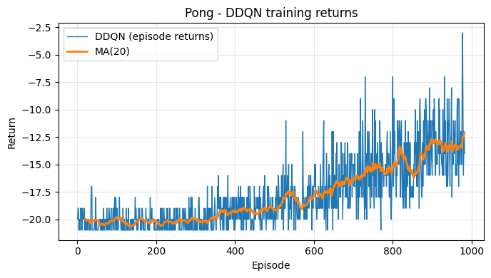

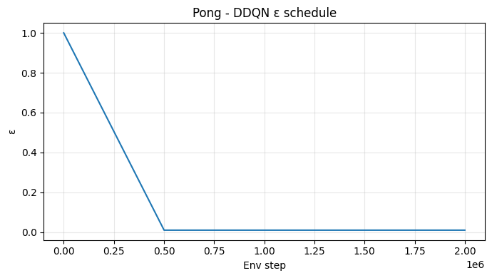

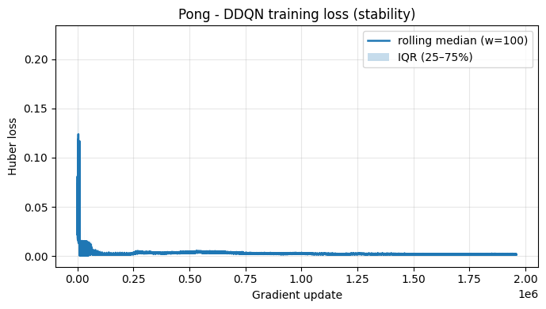

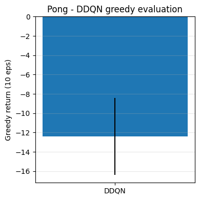

```
[DDQN Greedy] mean=-12.40, std=3.98, scores=[-17.0, -11.0, -4.0, -14.0, -10.0, -14.0, -10.0, -17.0, -10.0, -17.0]
```

```python
os.makedirs("artifacts", exist_ok=True)

# Episodic return (with MA(20))
plt.figure(figsize=(7,4))
plt.plot(np.arange(1, len(ddqn_returns)+1), ddqn_returns, linewidth=1, label="DDQN (episode returns)")
ma = moving_average(ddqn_returns, w=20)
if len(ma) > 0:
    xs = np.arange(20, 20+len(ma))
    plt.plot(xs, ma, linewidth=2, label="MA(20)")
plt.xlabel("Episode")
plt.ylabel("Return")
plt.title("Pong - DDQN training returns")
plt.grid(True, alpha=0.3)
plt.legend()
plt.tight_layout()
plt.savefig("artifacts/pong_ddqn_returns.png", dpi=150)
plt.show()
plt.close()

# Epsilon schedule vs steps
plt.figure(figsize=(7,4))
plt.plot(np.arange(1, len(ddqn_eps)+1), ddqn_eps, linewidth=1.5)
plt.xlabel("Env step")
plt.ylabel("ε")
plt.title("Pong - DDQN ε schedule")
plt.grid(True, alpha=0.3)
plt.tight_layout()
plt.savefig("artifacts/pong_ddqn_eps.png", dpi=150)
plt.show()
plt.close()

# Training loss (rolling median + IQR)
m, q25, q75 = rolling_quantiles(np.asarray(ddqn_loss, dtype=float), window=100)
plt.figure(figsize=(7,4))
if len(ddqn_loss) > 0:
    xs = np.arange(1, len(ddqn_loss)+1)
    plt.plot(xs, m, linewidth=1.8, label="rolling median (w=100)")
    plt.fill_between(xs, q25, q75, alpha=0.25, label="IQR (25–75%)")
plt.xlabel("Gradient update")
plt.ylabel("Huber loss")
plt.title("Pong - DDQN training loss (stability)")
plt.grid(True, alpha=0.3)
plt.legend()
plt.tight_layout()
plt.savefig("artifacts/pong_ddqn_loss_recent.png", dpi=150)
plt.show()
plt.close()

# Greedy evaluation (10 eps)
ddqn_policy.eval()
ddqn_scores = evaluate_greedy(ddqn_policy, ENV_ID, n_episodes=10, max_steps=20000, seed_base=SEED)
ddqn_policy.train()

ddqn_mean, ddqn_std = float(np.mean(ddqn_scores)), float(np.std(ddqn_scores))

np.savez_compressed("artifacts/pong_ddqn_greedy.npz",
                    scores=ddqn_scores, mean=np.array([ddqn_mean]), std=np.array([ddqn_std]))

plt.figure(figsize=(4,4))
plt.bar([0], [ddqn_mean], yerr=[ddqn_std], width=0.6)
plt.xticks([0], ["DDQN"])
plt.ylabel("Greedy return (10 eps)")
plt.title("Pong - DDQN greedy evaluation")
plt.grid(True, axis="y", alpha=0.3)
plt.tight_layout()
plt.savefig("artifacts/pong_ddqn_greedy_bar.png", dpi=150)
plt.show()
plt.close()

print(f"[DDQN Greedy] mean={ddqn_mean:.2f}, std={ddqn_std:.2f}, scores={ddqn_scores.tolist()}")
```

# **7.0 DQN vs DDQN - overlays & summary**

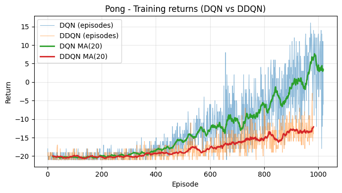

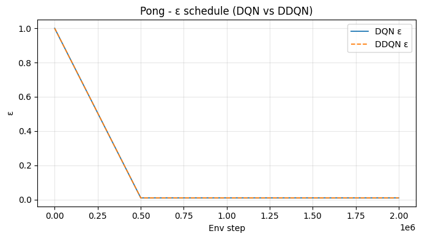

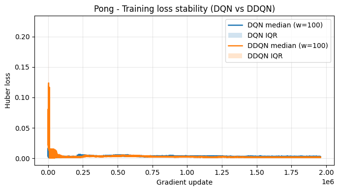

| Metric (last 50) | DQN | DDQN |
| --- | --- | --- |
| Mean return | 4.46 | -13.06 |
| Best return | 16.00 | -3.00 |
| Episodes ≥ −18 (count) | 50 | 50 |
| Episodes ≥ −18 (percent) | 100.0% | 100.0% |

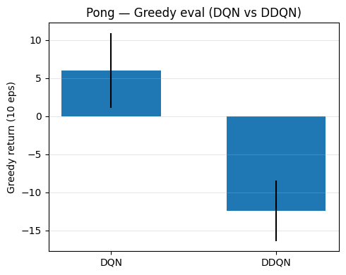

```python
os.makedirs("artifacts", exist_ok=True)

def try_get(name, globals_dict, fallback_path, key):
    if name in globals_dict and isinstance(globals_dict[name], (list, np.ndarray)):
        arr = np.asarray(globals_dict[name], dtype=float)
        if arr.size > 0:
            return arr
    data = np.load(fallback_path)
    return np.asarray(data[key], dtype=float)

# Training logs
dqn_returns_arr = try_get("dqn_returns", globals(), "artifacts/pong_dqn_logs.npz", "returns")
dqn_eps_arr     = try_get("dqn_eps",     globals(), "artifacts/pong_dqn_logs.npz", "eps")
dqn_loss_arr    = try_get("dqn_loss",    globals(), "artifacts/pong_dqn_logs.npz", "loss")

ddqn_returns_arr = try_get("ddqn_returns", globals(), "artifacts/pong_ddqn_logs.npz", "returns")
ddqn_eps_arr     = try_get("ddqn_eps",     globals(), "artifacts/pong_ddqn_logs.npz", "eps")
ddqn_loss_arr    = try_get("ddqn_loss",    globals(), "artifacts/pong_ddqn_logs.npz", "loss")

# Greedy results
dqn_g = np.load("artifacts/pong_dqn_greedy.npz")
ddqn_g = np.load("artifacts/pong_ddqn_greedy.npz")
dqn_scores, dqn_g_mean, dqn_g_std   = dqn_g["scores"], float(dqn_g["mean"][0]), float(dqn_g["std"][0])
ddqn_scores, ddqn_g_mean, ddqn_g_std = ddqn_g["scores"], float(ddqn_g["mean"][0]), float(ddqn_g["std"][0])

# Returns overlay (with MA20)
plt.figure(figsize=(7,4))
plt.plot(np.arange(1, len(dqn_returns_arr)+1), dqn_returns_arr, alpha=0.5, linewidth=0.8, label="DQN (episodes)")
plt.plot(np.arange(1, len(ddqn_returns_arr)+1), ddqn_returns_arr, alpha=0.5, linewidth=0.8, label="DDQN (episodes)")
ma_dqn  = moving_average(dqn_returns_arr, 20)
ma_ddqn = moving_average(ddqn_returns_arr, 20)
if len(ma_dqn) > 0:
    plt.plot(np.arange(20, 20+len(ma_dqn)), ma_dqn, linewidth=2.0, label="DQN MA(20)")
if len(ma_ddqn) > 0:
    plt.plot(np.arange(20, 20+len(ma_ddqn)), ma_ddqn, linewidth=2.0, label="DDQN MA(20)")
plt.xlabel("Episode"); plt.ylabel("Return")
plt.title("Pong - Training returns (DQN vs DDQN)")
plt.grid(True, alpha=0.3); plt.legend()
plt.tight_layout()
plt.savefig("artifacts/pong_dqn_ddqn_returns_overlay.png", dpi=150)
plt.show()

# Epsilon overlay
plt.figure(figsize=(7,4))
plt.plot(np.arange(1, len(dqn_eps_arr)+1), dqn_eps_arr, linewidth=1.3, label="DQN ε")
plt.plot(np.arange(1, len(ddqn_eps_arr)+1), ddqn_eps_arr, linewidth=1.3, label="DDQN ε", linestyle="--")
plt.xlabel("Env step"); plt.ylabel("ε")
plt.title("Pong - ε schedule (DQN vs DDQN)")
plt.grid(True, alpha=0.3); plt.legend()
plt.tight_layout()
plt.savefig("artifacts/pong_dqn_ddqn_eps_overlay.png", dpi=150)
plt.show()

# Loss stability overlay (rolling median + IQR)
m_dqn, q25_dqn, q75_dqn   = rolling_quantiles(np.asarray(dqn_loss_arr,  dtype=float), window=100)
m_ddqn, q25_ddqn, q75_ddqn = rolling_quantiles(np.asarray(ddqn_loss_arr, dtype=float), window=100)
plt.figure(figsize=(7,4))
xs_dqn  = np.arange(1, len(dqn_loss_arr)+1)
xs_ddqn = np.arange(1, len(ddqn_loss_arr)+1)
if len(dqn_loss_arr) > 0:
    plt.plot(xs_dqn, m_dqn, label="DQN median (w=100)", linewidth=1.8)
    plt.fill_between(xs_dqn, q25_dqn, q75_dqn, alpha=0.20, label="DQN IQR")
if len(ddqn_loss_arr) > 0:
    plt.plot(xs_ddqn, m_ddqn, label="DDQN median (w=100)", linewidth=1.8)
    plt.fill_between(xs_ddqn, q25_ddqn, q75_ddqn, alpha=0.20, label="DDQN IQR")
plt.xlabel("Gradient update"); plt.ylabel("Huber loss")
plt.title("Pong - Training loss stability (DQN vs DDQN)")
plt.grid(True, alpha=0.3); plt.legend()
plt.tight_layout()
plt.savefig("artifacts/pong_dqn_ddqn_loss_iqr_overlay.png", dpi=150)
plt.show()

# Compact metrics table (last 50 episodes)
def lastN_stats(arr, N=50):
    arr = np.asarray(arr, dtype=float)
    if arr.size == 0:
        return np.nan, np.nan, 0, np.nan
    tail = arr[-min(N, len(arr)):]
    mean = float(np.mean(tail))
    best = float(np.max(tail))
    ge_m18 = int(np.sum(tail >= -18.0))
    ge_m18_pct = 100.0 * ge_m18 / len(tail)
    return mean, best, ge_m18, ge_m18_pct

dqn_mean50, dqn_best50, dqn_ge18, dqn_ge18_pct   = lastN_stats(dqn_returns_arr, 50)
ddqn_mean50, ddqn_best50, ddqn_ge18, ddqn_ge18_pct = lastN_stats(ddqn_returns_arr, 50)

from IPython.display import display, HTML
html = f"""
<table>
<tr><th>Metric (last 50)</th><th>DQN</th><th>DDQN</th></tr>
<tr><td>Mean return</td><td>{dqn_mean50:.2f}</td><td>{ddqn_mean50:.2f}</td></tr>
<tr><td>Best return</td><td>{dqn_best50:.2f}</td><td>{ddqn_best50:.2f}</td></tr>
<tr><td>Episodes ≥ −18 (count)</td><td>{dqn_ge18}</td><td>{ddqn_ge18}</td></tr>
<tr><td>Episodes ≥ −18 (percent)</td><td>{dqn_ge18_pct:.1f}%</td><td>{ddqn_ge18_pct:.1f}%</td></tr>
</table>
"""
display(HTML(html))

# Greedy overlay bar (DQN vs DDQN)
plt.figure(figsize=(5,4))
means = [dqn_g_mean, ddqn_g_mean]
errs  = [dqn_g_std,  ddqn_g_std]
plt.bar([0,1], means, yerr=errs, width=0.6)
plt.xticks([0,1], ["DQN","DDQN"])
plt.ylabel("Greedy return (10 eps)")
plt.title("Pong — Greedy eval (DQN vs DDQN)")
plt.grid(True, axis="y", alpha=0.3)
plt.tight_layout()
plt.savefig("artifacts/pong_dqn_ddqn_greedy_bar.png", dpi=150)
plt.show()
```

# **8.0 Record a short gameplay clip (greedy policy)**

To show it actually plays, we create a fresh env with video recording enabled, run a few greedy episodes (ε≈0), and save an MP4.

```python
class CNNQNet(nn.Module):
    def __init__(self, in_channels: int, n_actions: int):
        super().__init__()
        self.features = nn.Sequential(
            nn.Conv2d(in_channels, 32, kernel_size=8, stride=4), nn.ReLU(inplace=True),
            nn.Conv2d(32, 64, kernel_size=4, stride=2),         nn.ReLU(inplace=True),
            nn.Conv2d(64, 64, kernel_size=3, stride=1),         nn.ReLU(inplace=True),
        )
        self.head = nn.Sequential(
            nn.Linear(3136, 512), nn.ReLU(inplace=True),
            nn.Linear(512, n_actions),
        )
        self.apply(self._init_weights)
    @staticmethod
    def _init_weights(m):
        if isinstance(m, (nn.Conv2d, nn.Linear)):
            nn.init.kaiming_normal_(m.weight, nonlinearity="relu")
            if m.bias is not None:
                nn.init.zeros_(m.bias)
    def forward(self, x: torch.Tensor) -> torch.Tensor:
        x = self.features(x)       # (B,64,7,7)
        x = x.view(x.size(0), -1)  # (B,3136)
        return self.head(x)        # (B,n_actions)

DEVICE = torch.device("cuda" if torch.cuda.is_available() else "cpu")
SEED = 1227
VID_DIR = pathlib.Path("artifacts/video"); VID_DIR.mkdir(parents=True, exist_ok=True)

def build_eval_env(prefix: str):
    env = gym.make("ALE/Pong-v5", frameskip=1, render_mode="rgb_array")
    env = AtariPreprocessing(env, grayscale_obs=True, screen_size=84, frame_skip=4, scale_obs=False)
    env = FrameStackObservation(env, stack_size=4)
    env = RecordVideo(env, video_folder=str(VID_DIR), name_prefix=prefix)
    return env

@torch.no_grad()
def obs_to_tensor(obs):
    x = torch.tensor(obs, dtype=torch.float32, device=DEVICE).unsqueeze(0) / 255.0
    return x

@torch.no_grad()
def play_one_episode(env, policy_net, max_steps=50_000, seed=SEED):
    obs, _ = env.reset(seed=seed)
    s = obs_to_tensor(obs)
    total = 0.0
    for _ in range(max_steps):
        a = int(policy_net(s).argmax(1).item())
        obs, r, term, trunc, _ = env.step(a)
        total += float(r)
        if term or trunc:
            break
        s = obs_to_tensor(obs)
    return total

def load_policy(weights_path: str):
    tmp = gym.make("ALE/Pong-v5", frameskip=1)
    n_actions = tmp.action_space.n
    tmp.close()
    net = CNNQNet(in_channels=4, n_actions=n_actions).to(DEVICE).eval()
    state = torch.load(weights_path, map_location=DEVICE)
    # handle wrapped checkpoints gracefully
    if isinstance(state, dict):
        for k in ["model_state_dict", "state_dict", "policy", "net"]:
            if k in state and isinstance(state[k], dict):
                state = state[k]; break
    net.load_state_dict(state, strict=True)
    return net

def record_clip(weights_path: str, prefix: str, seed_offset=0):
    policy = load_policy(weights_path)
    env = build_eval_env(prefix)
    ret = play_one_episode(env, policy, max_steps=50_000, seed=SEED)
    env.close()
    print(f"[Video] {prefix} greedy return: {ret:.2f}")
    print(f"Saved MP4s in: {VID_DIR.resolve()}")

if __name__ == "__main__":
    record_clip("artifacts/pong_dqn_policy.pth",  "pong_dqn_greedy",  seed_offset=SEED)
    record_clip("artifacts/pong_ddqn_policy.pth", "pong_ddqn_greedy", seed_offset=SEED)
```

```
[Video] pong_dqn_greedy greedy return: 12.00
Saved MP4s in: /content/artifacts/video
[Video] pong_ddqn_greedy greedy return: -10.00
Saved MP4s in: /content/artifacts/video
```